# investment_tools

## This is the code to copy/paste into an R script or markdown file.

```r
install.packages(c("stringr", "rvest", "lubridate", "xml2"))
```

```r
library(stringr)
library(rvest)
library(xml2)
library(lubridate)
```

```r
urlTables <- function(url, ...) {
    rvest_installed <- "rvest" %in% rownames(installed.packages())
    if(!rvest_installed) {
         return(print("Install rvest first"))
    }
    website <- read_html(url)
    list <- html_table(website, ...)
    list
}

# Used to shift vectors
shift <- function (x, shift_by)  {
    stopifnot(is.numeric(shift_by))
    stopifnot(is.numeric(x))
    if (length(shift_by) > 1)
        return(sapply(shift_by, shift, x = x))
    out <- NULL
    abs_shift_by = abs(shift_by)
    if (shift_by > 0)
        out <- c(tail(x, -abs_shift_by), rep(NA, abs_shift_by))
    else if (shift_by < 0)
        out <- c(rep(NA, abs_shift_by), head(x, -abs_shift_by))
    else out <- x
    out
}

# Returns first day of month in a vector of dates,
# if by_year = TRUE, returns first day of year.
first_day <- function (x = "Vector of Dates", by_year = FALSE) {
    x = as.Date(as.character(x))
    day = format(x, format = "%d")
    monthYr = format(x, format = "%Y-%m")
    y = tapply(day, monthYr, min)
    first = as.Date(paste(row.names(y), y, sep = "-"))
    if (by_year) {
         first = first[grepl("[[:digit:]]+-01-[[:digit:]]+", first)]
    }
    return(as.factor(first))
}


# Used to get divided data from various sources
div_data <- function(ticker, NASDAQ=FALSE, DIVIDATA = FALSE,...) {
    rvest_installed <- "rvest" %in% rownames(installed.packages())
    if(!rvest_installed) {
         return(print("Install rvest first"))
    }
    if (NASDAQ) {
        website <- xml2::read_html(paste0("http://www.nasdaq.com/symbol/",
                                          ticker, "/dividend-history"))
        list <- rvest::html_table(website, ...)
        list <- list[[6]]
        col_names <- sub(" ", "", names(list))
        col_names[1] <- "ExEffDate"
        names(list) <- col_names
        list$ExEffDate <- as.Date(list$ExEffDate, "%m/%d/%Y")
        list$DeclarationDate <- as.Date(list$DeclarationDate, "%m/%d/%Y")
        list$RecordDate <- as.Date(list$RecordDate, "%m/%d/%Y")
        list$PaymentDate <- as.Date(list$PaymentDate, "%m/%d/%Y")
        return(list)
    }
    if(DIVIDATA) {
        website <- xml2::read_html(paste0("https://dividata.com/stock/",
                                          ticker,"/dividend"))
        list <- rvest::html_table(website, ...)
        exDivDate <- list[[1]][,1]
        dividend <- list[[1]][,2]
        exDivDate <- as.Date(exDivDate, format = "%B %d, %Y")
        dividend <- sub("\\$", "", dividend)
        data.frame(Date = exDivDate, ex_dividend = as.numeric(dividend))
    }
    website <- read.csv(
               paste0("http://chart.finance.yahoo.com/table.csv?s=",ticker
                      ,"&a=0&b=2&c=1962&d=0&e=26&f=2017&g=v&ignore=.csv")
               )
    website$Date <- as.Date(website$Date)
    website
}
```

```r
stock_quote <- function (stockName = "vector of tickers", year = 1900, day = 1, month = 1)  {
    lubridate_installed <- "lubridate" %in% rownames(installed.packages())
    if(!lubridate_installed) {
         return(print("First, install the package 'lubridate'."))
    }
    returnIt <- list(NA)
    if (missing(year)) {
        year <- 1000
    }
    returnList <- list(NA)
    cur_date <- Sys.Date()
    cur_year <- format(cur_date, "%Y")
    cur_month <- format(cur_date, "%m")
    cur_day <- format(cur_date, "%d")

    for (i in 1:length(stockName)) {
        url <- paste0("http://chart.finance.yahoo.com/table.csv?s=",stockName[i],
                      "&a=", month-1, "&b=", day, "&c=", year, "&d=", cur_month,
                      "&e=",cur_day,"&f=", cur_year,"&g=d&ignore=.csv")

        # Cleaning up by day data.
        byDay <- read.csv(url)
        byDay$Date <- as.Date(byDay$Date)
        byDay <- subset(byDay, Date > as.Date(paste0(year, "-01-01")))
        byDay$Date <- as.Date(byDay$Date)

        # Get dividends
        divs <- div_data(stockName[i])

        byDay = merge.data.frame(divs, byDay, by="Date", all.y = TRUE)
        byDay[is.na(byDay)] = 0
        #return(divs)aap
        # Cleaning up by week
        byWeek <- subset(byDay, lubridate::wday(byDay$Date) == 2)
        rownames(byWeek) <- NULL

        # Cleaning up by month
        byMonth <- data.frame(Date = as.Date(first_day(byDay$Date)))
        byMonth <- merge(byDay, byMonth)
        byMonth <- byMonth[order(byMonth$Date, decreasing = TRUE), ]
        rownames(byMonth) <- NULL

        # Cleaning up by year
        byYear <- data.frame(Date = as.Date(first_day(byDay$Date, by_year = TRUE)))
        byYear <- merge(byYear, byDay)
        byYear <- byYear[order(byYear$Date, decreasing = TRUE), ]
        rownames(byYear) <- NULL

                byDay <- byDay[order(byDay$Date, decreasing = TRUE), ]

        byDay$Percent.Change <- (byDay$Close - shift(byDay$Close, 1))/shift(byDay$Close, 1) * 100
        byDay$Ri <- log((byDay$Close + byDay$Dividends)/shift(byDay$Close, 1))
        byDay$WriM1 <- exp(byDay$Ri)-1
        byDay$logRet <- cumsum(byDay$WriM1)
        byMonth$Percent.Change <- (byMonth$Close - shift(byMonth$Close, 1))/shift(byMonth$Close, 1) * 100
        byYear$Percent.Change <- (byYear$Close - shift(byYear$Close, 1))/shift(byYear$Close, 1) * 100
        byWeek$Percent.Change <- (byWeek$Close - shift(byWeek$Close, 1))/shift(byWeek$Close, 1) * 100


        returnList$byDay <- byDay
        returnList$byMonth <- byMonth
        returnList$byYear <- byYear
        returnList$byWeek <- byWeek
        returnIt[[stockName[i]]] <- returnList
        returnIt[[stockName[i]]] <- returnIt[[stockName[i]]][-1]
    }
    returnIt <- returnIt[-1]
    return(returnIt)
}
```

# Now lets play and use the code

Create a vector with the stock tickers you wish to lookup.

```r
tickers <- c("SPY", "AKRX", "GE", "GLD", "TIP", "GOOG", "AKAM", "SIFY")
```

Next, use the `stock_quote()` function to get the information desired. You can select a specific date by using the arguments `year = whatever`, `day = whatever`, `month = whatever`. If you do not select `year`, `day`, or `month` the function will default to the oldest possible date.

```r
stocks <- stock_quote(tickers, year = 2006, day = 1, month = 1)
```

```r
# Options under stocks
names(stocks)
```

```
## [1] "SPY"  "AKRX" "GE"   "GLD"  "TIP"  "GOOG" "AKAM" "SIFY"
```

```r
# Options under a particular stock
names(stocks$SPY)
```

```
## [1] "byDay"   "byMonth" "byYear"  "byWeek"
```

```r
# data.frame of SPY byDay
# I NEED TO CLEAN UP AND VERIFY ACCURACY FOR Ri, WRI minus 1 and logRet
# DO NOT TRUST THOSE
# AS WELL, OLD DIVIDEND DATA DOES NOT ALWAYS SHOW UP. I AM PULLING FROM YAHOO
names(stocks$SPY$byDay)
```

```
##  [1] "Date"           "Dividends"      "Open"           "High"
##  [5] "Low"            "Close"          "Volume"         "Adj.Close"
##  [9] "Percent.Change" "Ri"             "WriM1"          "logRet"
```

```r
# Look at the top of the data.frame for SPY
head(stocks$SPY$byDay)
```

```
##            Date Dividends   Open   High    Low  Close    Volume Adj.Close
## 2786 2017-01-26         0 229.40 229.71 229.01 229.33  58208000    229.33
## 2785 2017-01-25         0 228.70 229.57 228.51 229.57  80932500    229.57
## 2784 2017-01-24         0 226.40 228.08 226.27 227.60  89144800    227.60
## 2783 2017-01-23         0 226.74 226.81 225.27 226.15  72331900    226.15
## 2782 2017-01-20         0 226.70 227.31 225.97 226.74 116431700    226.74
## 2781 2017-01-19         0 226.84 227.00 225.41 225.91  65357500    225.91
##      Percent.Change           Ri        WriM1       logRet
## 2786     -0.1045455 -0.001046001 -0.001045455 -0.001045455
## 2785      0.8655540  0.008618296  0.008655540  0.007610086
## 2784      0.6411727  0.006391259  0.006411727  0.014021813
## 2783     -0.2602148 -0.002605539 -0.002602148  0.011419665
## 2782      0.3674034  0.003667301  0.003674034  0.015093699
## 2781     -0.3704503 -0.003711381 -0.003704503  0.011389196
```

### Plot all the data

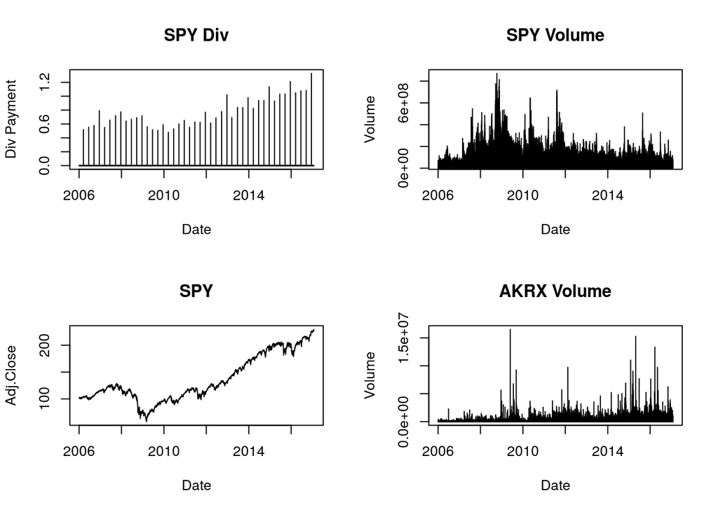

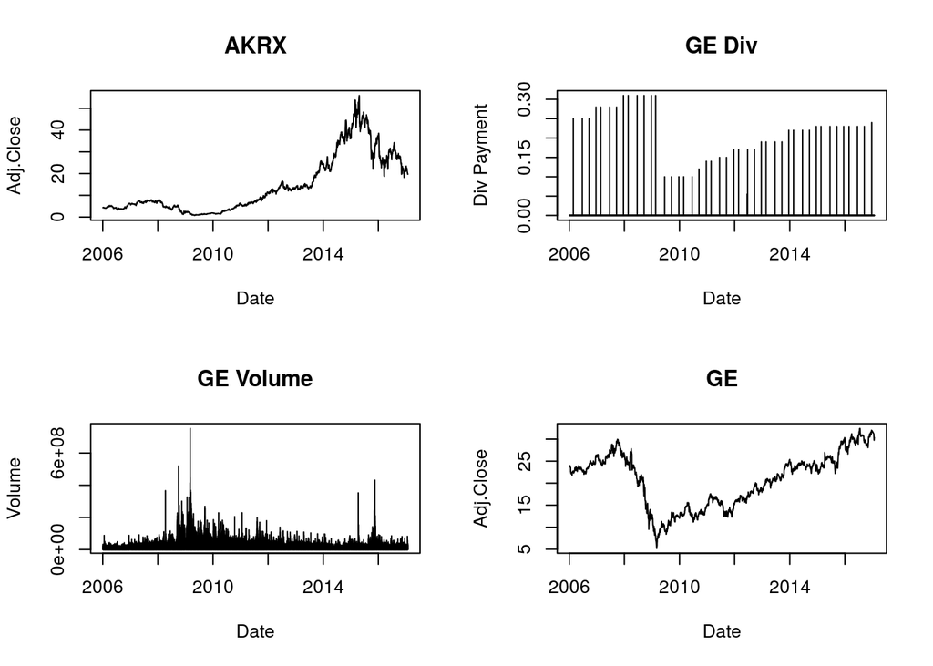

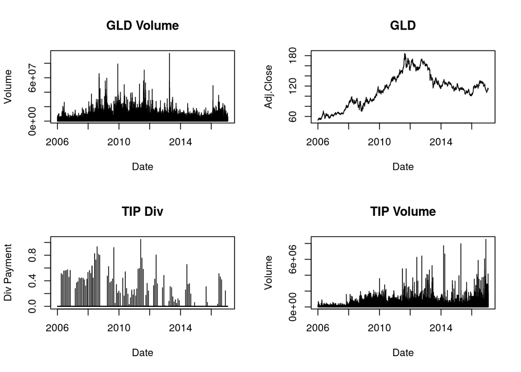

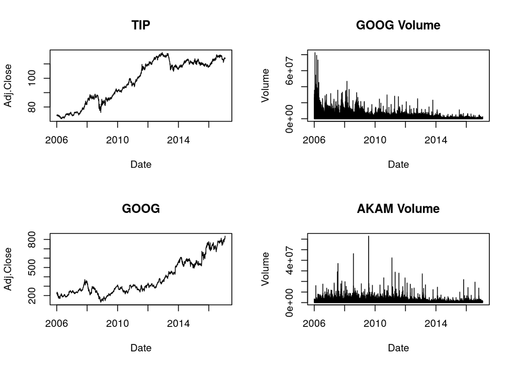

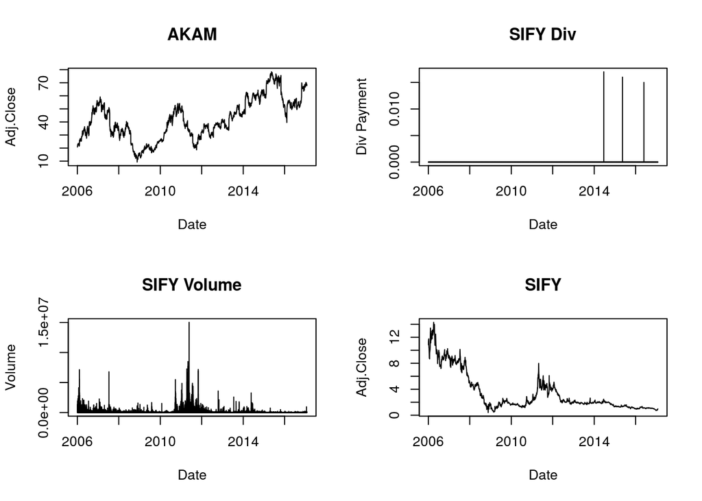

```r
par(mfrow = c(2,2))
for(i in seq_along(tickers)) {
     # Only plotting dividends if the stock has dividends thus "if the sum of stocks is greater than 0, then plot that dividend"
     if(sum(stocks[[i]]$byDay$Dividends)!=0) {
               plot(stocks[[i]]$byDay$Date,
                    stocks[[i]]$byDay$Dividends,
                    type = "h",
                    xlab = "Date",
                    ylab = "Div Payment",
                    main = paste(tickers[i], "Div"))
     }
     plot(stocks[[i]]$byDay$Date, stocks[[i]]$byDay$Volume, type = "h", xlab = "Date", ylab = "Volume", main =paste(tickers[i], "Volume"))
     plot(stocks[[i]]$byDay$Date, stocks[[i]]$byDay$Adj.Close, type = "l", xlab = "Date", ylab = "Adj.Close", main = paste(tickers[i]))
}
```

Now let’s create a correlation matrix. I understand that we’re learning new ways to do this in our class. Once I verify that my dividend information is correct and I learn how to create the average correlation we talked about in class, I’ll update the code.

```r
# Initialize a matrix full of 0's with a row length as the length of the date vector and colmns as the length of the number of stocks
adj_close_mat <- matrix(0, nrow = length(stocks$SPY$byDay$Date), ncol = length(tickers))
colnames(adj_close_mat) <- tickers
for(i in seq_along(tickers)) {
     adj_close_mat[,i] <- stocks[[i]]$byDay$Adj.Close
}

cor(adj_close_mat)
```

```
##             SPY       AKRX         GE         GLD        TIP       GOOG
## SPY   1.0000000  0.9061921  0.7442721  0.24142194  0.6906071  0.9557560
## AKRX  0.9061921  1.0000000  0.5608547  0.25092597  0.6761644  0.8264339
## GE    0.7442721  0.5608547  1.0000000 -0.26636714  0.1440610  0.6499785
## GLD   0.2414219  0.2509260 -0.2663671  1.00000000  0.8372445  0.2844393
## TIP   0.6906071  0.6761644  0.1440610  0.83724448  1.0000000  0.7171353
## GOOG  0.9557560  0.8264339  0.6499785  0.28443930  0.7171353  1.0000000
## AKAM  0.8387630  0.7918618  0.6502272  0.09054871  0.4677965  0.7425254
## SIFY -0.3625562 -0.4063833  0.2093710 -0.55769926 -0.6974006 -0.4934025
##             AKAM       SIFY
## SPY   0.83876300 -0.3625562
## AKRX  0.79186184 -0.4063833
## GE    0.65022720  0.2093710
## GLD   0.09054871 -0.5576993
## TIP   0.46779648 -0.6974006
## GOOG  0.74252539 -0.4934025
## AKAM  1.00000000 -0.1938779
## SIFY -0.19387791  1.0000000
```

Now let’s do something cool. Say we wanted to download the entire S&P. I’m NOT going to sit here and type in tickers all day. However, if we wanted to, we could. Let’s use the function urlTables I wrote above to strip data from wikipedia.

```r
sNp_tickers <- urlTables("https://en.wikipedia.org/wiki/List_of_S%26P_500_companies", fill = TRUE)

tickers <- sNp_tickers[[1]]$`Ticker symbol`
```

```r
# Just to prove we have them
tickers
```

```
##   [1] "MMM"   "ABT"   "ABBV"  "ACN"   "ATVI"  "AYI"   "ADBE"  "AAP"
##   [9] "AES"   "AET"   "AMG"   "AFL"   "A"     "APD"   "AKAM"  "ALK"
##  [17] "ALB"   "AGN"   "LNT"   "ALXN"  "ALLE"  "ADS"   "ALL"   "GOOGL"
##  [25] "GOOG"  "MO"    "AMZN"  "AEE"   "AAL"   "AEP"   "AXP"   "AIG"
##  [33] "AMT"   "AWK"   "AMP"   "ABC"   "AME"   "AMGN"  "APH"   "APC"
##  [41] "ADI"   "ANTM"  "AON"   "APA"   "AIV"   "AAPL"  "AMAT"  "ADM"
##  [49] "ARNC"  "AJG"   "AIZ"   "T"     "ADSK"  "ADP"   "AN"    "AZO"
##  [57] "AVB"   "AVY"   "BHI"   "BLL"   "BAC"   "BK"    "BCR"   "BAX"
##  [65] "BBT"   "BDX"   "BBBY"  "BRK-B" "BBY"   "BIIB"  "BLK"   "HRB"
##  [73] "BA"    "BWA"   "BXP"   "BSX"   "BMY"   "AVGO"  "BF-B"  "CHRW"
##  [81] "CA"    "COG"   "CPB"   "COF"   "CAH"   "HSIC"  "KMX"   "CCL"
##  [89] "CAT"   "CBG"   "CBS"   "CELG"  "CNC"   "CNP"   "CTL"   "CERN"
##  [97] "CF"    "SCHW"  "CHTR"  "CHK"   "CVX"   "CMG"   "CB"    "CHD"
## [105] "CI"    "XEC"   "CINF"  "CTAS"  "CSCO"  "C"     "CFG"   "CTXS"
## [113] "CLX"   "CME"   "CMS"   "COH"   "KO"    "CTSH"  "CL"    "CMCSA"
```

[output cut: 49 more lines]

```r
# Download all the stock data
stocks <- stock_quote(tickers, year = 2017, day = 20, month = 1)
```

Here’s a correlation matrix of the entire S&P 500 over the past week. Is it useful? I don’t have a clue, but you could do it if you wanted to.

```r
# Initialize a matrix full of 0's with a row length as the length of the date vector and colmns as the length of the number of stocks
adj_close_mat <- matrix(0, nrow = length(stocks[[1]]$byDay$Date), ncol = length(tickers))
colnames(adj_close_mat) <- tickers
for(i in seq_along(tickers)) {
     adj_close_mat[,i] <- stocks[[i]]$byDay$Adj.Close
}
corr_mat <- cor(adj_close_mat)

# Dimensions of the correlation matrix
dim(corr_mat)
```

```
## [1] 505 505
```

```r
# Only plotting the first 10 rows and columns
corr_mat[1:10,1:10]
```

```
##              MMM         ABT        ABBV        ACN       ATVI        AYI
## MMM   1.00000000 -0.07937866  0.23802736 -0.7943963 -0.6794716 -0.6303604
## ABT  -0.07937866  1.00000000  0.40249433 -0.1609208  0.3962999  0.6588616
## ABBV  0.23802736  0.40249433  1.00000000  0.2092806  0.5169378  0.5193099
## ACN  -0.79439632 -0.16092084  0.20928056  1.0000000  0.8094222  0.6277150
## ATVI -0.67947161  0.39629991  0.51693780  0.8094222  1.0000000  0.9046818
## AYI  -0.63036040  0.65886163  0.51930986  0.6277150  0.9046818  1.0000000
## ADBE -0.92929387 -0.04074660  0.02281220  0.9515381  0.7727989  0.6827582
## AAP   0.50482957 -0.49886442 -0.18044329 -0.3574608 -0.4170499 -0.7228476
## AES  -0.14667856 -0.52338387 -0.09469015  0.3545743  0.2093635 -0.2201570
## AET   0.75055397 -0.24030977  0.28412877 -0.4308406 -0.3134469 -0.5413600
##            ADBE        AAP         AES        AET
## MMM  -0.9292939  0.5048296 -0.14667856  0.7505540
## ABT  -0.0407466 -0.4988644 -0.52338387 -0.2403098
## ABBV  0.0228122 -0.1804433 -0.09469015  0.2841288
## ACN   0.9515381 -0.3574608  0.35457431 -0.4308406
## ATVI  0.7727989 -0.4170499  0.20936347 -0.3134469
## AYI   0.6827582 -0.7228476 -0.22015702 -0.5413600
## ADBE  1.0000000 -0.5333046  0.17604339 -0.6707194
## AAP  -0.5333046  1.0000000  0.73213832  0.8694301
## AES   0.1760434  0.7321383  1.00000000  0.5124873
## AET  -0.6707194  0.8694301  0.51248734  1.0000000
```